# Clustering Lab

Sam Muir

2024-02-29

We’ll start off with some simulated data that has a structure that is amenable to clustering analysis.

```r
#Set the parameters of our simulated data
set.seed(101)

cents <- tibble(cluster = factor(1:3),
                num_points = c(100,150,50),
                x1 = c(5,0,-3),
                x2 = c(-1,1,-2))
```

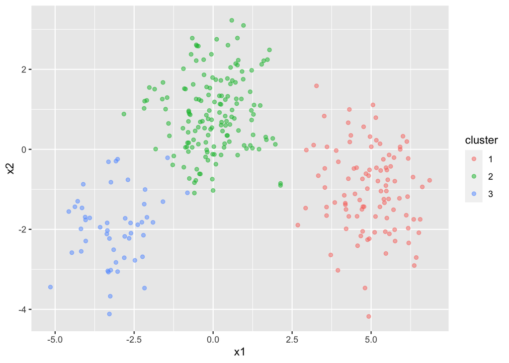

```r
#Simulate the data by passing n and mean to rnorm using map2()

labelled_pts <- cents %>%
  mutate(x1 = map2(num_points, x1, rnorm),
         x2 = map2(num_points, x2, rnorm)) %>%
  select(-num_points)  %>%
  unnest(cols = c(x1,x2))

ggplot(labelled_pts, aes(x1, x2, color = cluster)) +
  geom_point(alpha = 0.5)
```

```r
points <- labelled_pts %>%
  select(-cluster)

kclust <- kmeans(points, centers = 3, n = 1)
kclust
```

```
## K-means clustering with 3 clusters of sizes 48, 100, 152
##
## Cluster means:
##             x1         x2
## 1 -3.194015379 -2.0272690
## 2  4.962808900 -1.0254665
## 3 -0.004476705  0.8627456
##
## Clustering vector:
##   [1] 2 2 2 2 2 2 2 2 2 2 2 2 2 2 2 2 2 2 2 2 2 2 2 2 2 2 2 2 2 2 2 2 2 2 2 2 2
##  [38] 2 2 2 2 2 2 2 2 2 2 2 2 2 2 2 2 2 2 2 2 2 2 2 2 2 2 2 2 2 2 2 2 2 2 2 2 2
##  [75] 2 2 2 2 2 2 2 2 2 2 2 2 2 2 2 2 2 2 2 2 2 2 2 2 2 2 3 3 3 3 3 3 3 3 3 3 3
## [112] 3 3 3 3 3 3 3 3 3 3 3 3 3 3 3 3 3 3 3 3 3 3 3 3 3 3 3 3 3 3 3 3 3 3 3 3 3
## [149] 3 3 3 3 3 3 3 3 3 3 3 3 3 3 3 3 3 3 3 3 3 3 3 3 3 3 3 3 3 3 3 3 3 3 3 3 3
## [186] 3 3 3 3 3 3 3 3 3 3 3 3 3 3 3 3 3 3 3 3 3 3 3 3 3 3 3 3 3 3 3 3 3 3 3 3 3
## [223] 3 3 3 3 3 3 3 3 3 3 3 3 3 3 3 3 3 3 3 3 3 3 3 3 3 3 3 3 1 1 1 1 1 1 1 1 1
## [260] 1 1 1 3 1 3 1 1 1 1 1 1 1 1 1 1 1 1 1 1 1 1 1 1 1 1 1 1 1 1 1 1 1 1 1 1 1
## [297] 1 1 1 1
##
## Within cluster sum of squares by cluster:
## [1]  66.89755 195.90406 277.61532
##  (between_SS / total_SS =  84.6 %)
##
## Available components:
##
## [1] "cluster"      "centers"      "totss"        "withinss"     "tot.withinss"
## [6] "betweenss"    "size"         "iter"         "ifault"
```

```r
#now let's try a systematic method for setting k
kclusts <- tibble(k = 1:9) %>%
  mutate(kclust = map(k, ~kmeans(points, .x)),
         augmented = map(kclust, augment, points))
```

```r
#append cluster assignment to tibble
assignments <- kclusts %>%
  unnest(cols = c(augmented))
```

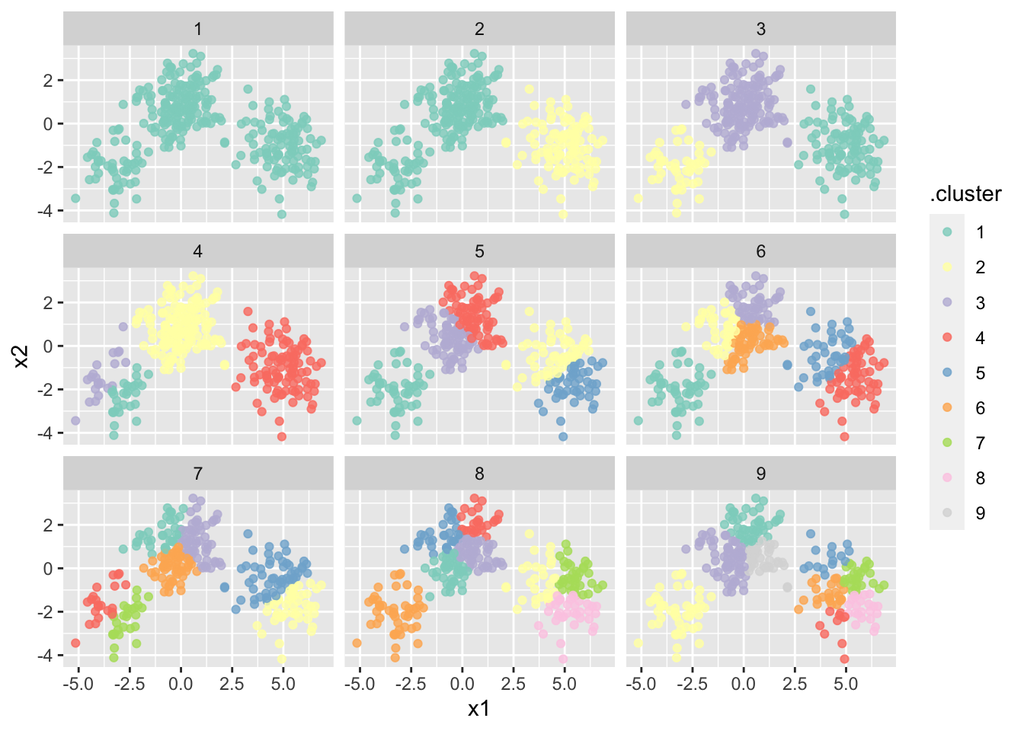

```r
#Plot each model
p1 <- ggplot(assignments, aes(x = x1, y = x2)) +
  geom_point(aes(color = .cluster), alpha = 0.8) +
  scale_color_brewer(palette = "Set3") +
  facet_wrap(~k)
p1
```

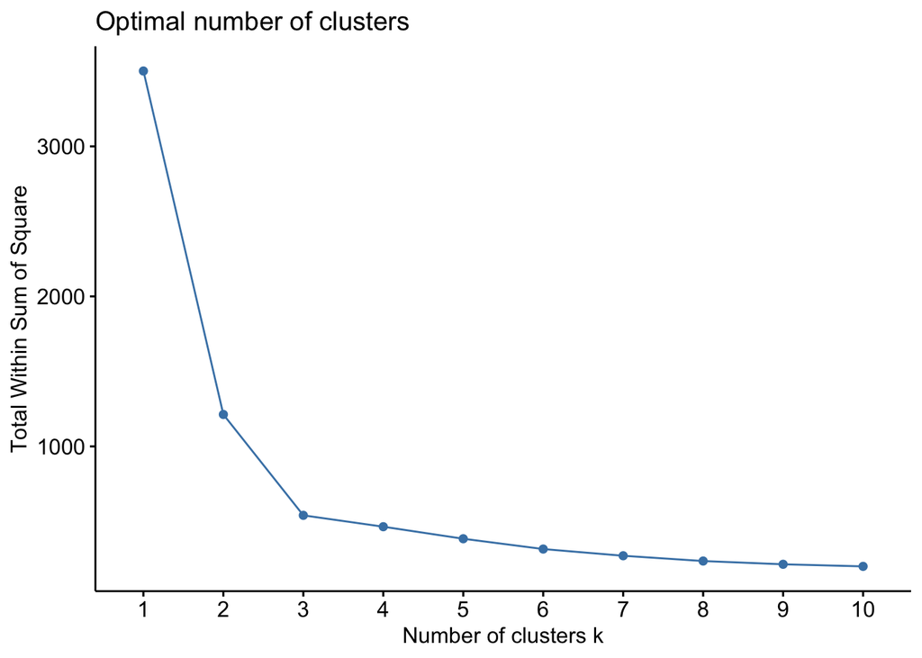

```r
#Use a clustering function from {factoextra} to plot  total WSSs
fviz_nbclust(points, kmeans, "wss")
```

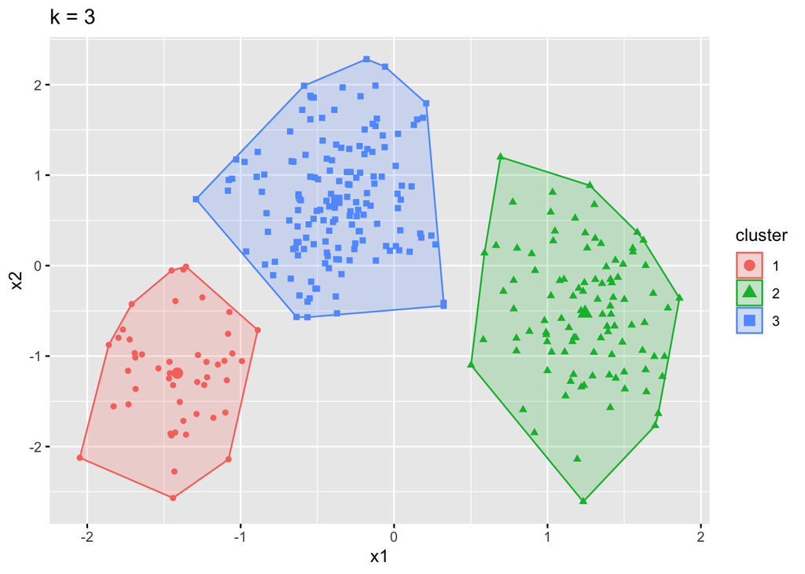

```r
#Another plotting method
k3 <- kmeans(points, centers = 3, nstart = 25)

fviz_cluster(k3, geom = "point", data = points) +
  ggtitle("k = 3")
```

In-class assignment!

Now it’s your turn to partition a dataset. For this round we’ll use data from Roberts et al. 2008 on bio-contaminants in Sydney Australia’s Port Jackson Bay. The data are measurements of metal content in two types of co-occurring algae at 10 sample sites around the bay.

```r
#Read in data
metals_dat <- readr::read_csv(here::here("week-8/Harbour_metals.csv"))

# Inspect the data
head(metals_dat)
```

```
## # A tibble: 6 × 10
##   Location   Species Rep      Cd    Cr    Cu    Mn    Ni    Pb    Zn
##   <chr>      <chr>   <chr> <dbl> <dbl> <dbl> <dbl> <dbl> <dbl> <dbl>
## 1 Balls Head Padina  P.13   0.67  3.82  68.9 107.   1.52  32.6  96.5
## 2 Balls Head Padina  P.14   0.5   5.84  93.5  82.0  2.74  28.8 135.
## 3 Balls Head Padina  P.15   0.66  9.04 116.  124.   3.17  62.1 151.
## 4 Balls Head Padina  P.16   0.89  4.93 111.  156.   2.43  52.5 114.
## 5 Balls Head Padina  P.17   0.86  4.35 117.  161.   1.62  47.8 126.
## 6 Balls Head Padina  P.18   0.78  8.68 110.  167.   4.16  71.6 130.
```

```r
#Grab pollutant variables
metals_dat2 <- metals_dat[, 4:8]
```

1. Start with k-means clustering - kmeans(). You can start with fviz_nbclust() to identify the best value of k. Then plot the model you obtain with the optimal value of k.

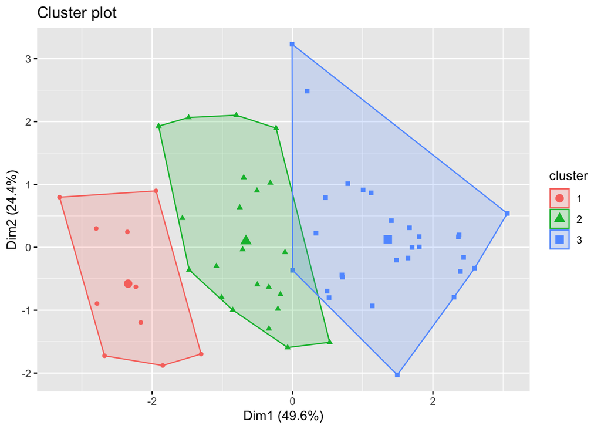

```r
mod1 <- fviz_nbclust(metals_dat2, kmeans, "wss")

k3 <- kmeans(metals_dat2, centers = 3, nstart = 25)
fviz_cluster(k3, geom = "point", data = metals_dat2)
```

Do you notice anything different about the spacing between clusters? Why might this be?

**- There is some overlap between the clusters. This might indicate there there are not actually 3 clusters and that what think is the optimal k from fviz_nbclust is not really the optimal k.**

Run summary() on your model object. Does anything stand out?

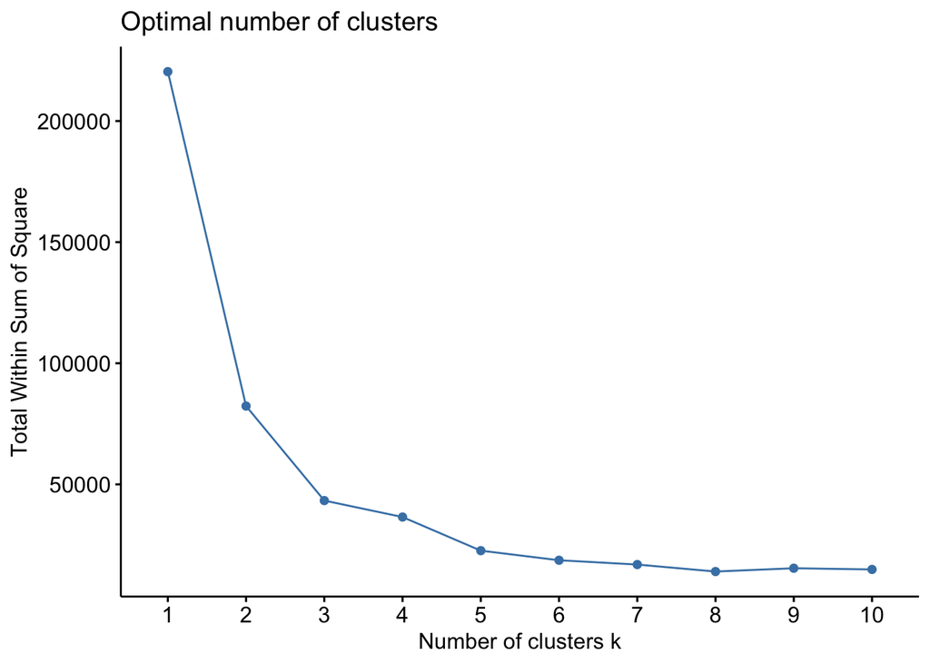

```r
mod1
```

**Looking at the mdodel, it seems like the elbow is at 3 clusters**

2. Good, now let’s move to hierarchical clustering that we saw in lecture. The first step for that is to calculate a distance matrix on the data (using dist()). Euclidean is a good choice for the distance method.

```r
#get_dist()
dist_euc <- dist(metals_dat2, method = "euclidean")
```

2. Use tidy() on the distance matrix so you can see what is going on. What does each row in the resulting table represent?

```r
tidy(dist_euc)
```

```
## # A tibble: 1,770 × 3
##    item1 item2 distance
##    <fct> <fct>    <dbl>
##  1 1     2         35.1
##  2 1     3         50.5
##  3 1     4         64.3
##  4 1     5         72.5
##  5 1     6         72.6
##  6 1     7        103.
##  7 1     8         11.4
##  8 1     9         22.4
##  9 1     10        45.1
## 10 1     11        23.3
## # ℹ 1,760 more rows
```

**Each row in the table is the euclidean distance between the item1 and item2.**

3. Then apply hierarchical clustering with hclust().

```r
metal_clust <- hclust(dist_euc)
```

4. Now plot the clustering object. You can use something of the form plot(as.dendrogram()). Or you can check out the cool visual options here: https://rpubs.com/gaston/dendrograms

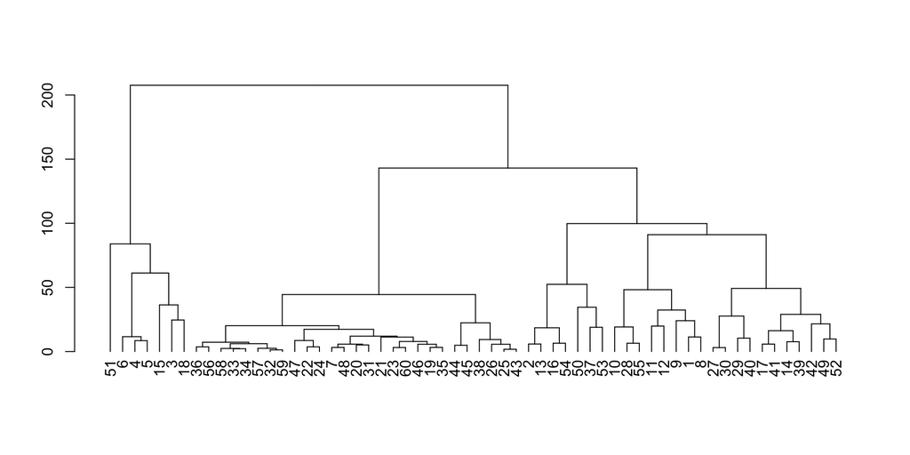

```r
plot(as.dendrogram(metal_clust))
```

How does the plot look? Do you see any outliers? How can you tell?